# Coursework report

*N* removed NAs: 2

*N* removed typo: 1

*N* removed <18: 23

*N* total clean: 124

| Group | *N* | *M*<sub>age</sub> | *M*<sub>rating</sub> |
| --- | --- | --- | --- |
| Control | 57 | 20.74 | 6.42 |
| Experim | 67 | 20.27 | 5.52 |

**Main analysis results**

*t*(122) = 6.65, *p* < .001

[interactive chart not shown]

[figure not shown]

[interactive chart not shown]

# Coursework report

Analysing Data, Spring 2020

# Methods

## Participants

*Table 1. Descriptive statistics for age*

| *Mean*<sub>age</sub> | *SD*<sub>age</sub> | *Min*<sub>age</sub> | *Max*<sub>age</sub> |
| --- | --- | --- | --- |
| 20.48 | 1.96 | 18 | 29 |

The table above (table 1) shows the mean age for participants (20.48), the Standard deviation for the participants (1.96), the minimum age which was 18 and the maximum age which was 29.

## Design

Elliots 2010 original study was set up to explore the impact of the red effect on increasing attractiveness perception. This study hypothesises that women perceive men to be more attractive and sexually desirable when they are seen on a red background and they are in red clothing. The null hypothesis suggests that there will be no difference in the percieved attractiveness rating when the man is on a red background compared to a white background. In this study, there were two conditions. The control condition viewed an image of a man with a white background, and the experimental condition viewed a man with a red background. Their level of attractiveness that they rated the man was recorded by asking questions to the women, and their response measured on a scale of 1 to 9, with 9 being very attractive. These were “How attractive do you think this person is” “How pleasant is the person to look at” and “If I were to meet this person face to face, would I find them attractive?” In order to test the results and their significance, a T test will be used to test the results in the conditions.

# Results

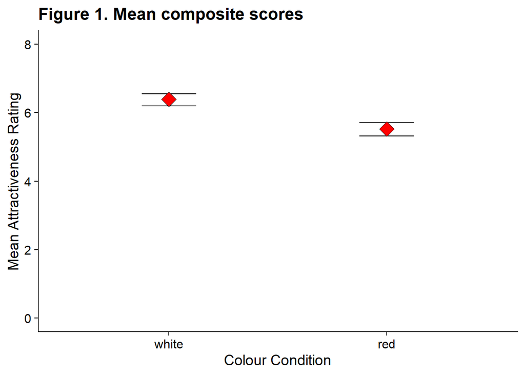

# Discussion

This study investigated the rating of attractiveness when images have a red or a white background. The results showed that there was a slight increase in the rating of attractiveness when images had the white background in comparison to when the image had the red background. The T-test suggests that the difference between condition one and condition two is also significant. These results contribute to the research area because they disagree with Elliot et al’s original study, the results of this repetition study are different. In Elliot’s original study, the mean composite score in the red condition was 6.67 and 5.67 in the white condition (Elliot et al., 2010). In comparison with our results, this study showed a 5.5 composite score in the red condition and 6.4 in the white condition. This shows that the white group showed a higher mean composite score than in the red group, whereas Elliot’s study showed a higher mean score in the red group. This could be because Elliot’s study has replication biases, meaning that our replication was not likely to correlate with the same or similar results. This study can be correlated with results by other studies in showing that there is no red effect on perceived attractiveness. Hesslinger replicated Elliot et al’s 2010 study, but he used a much larger sample of participants. Despite this though, they still did not find an effect of red on perceived attractiveness (Hesslinger, Goldbach, & Carbon, 2015). This correlates with our results, as we found the same or a similar pattern of results in showing that there is not much correlation with the colour red on attractiveness as originally thought by Elliot. This means that the colour red does not have an effect on perceived attractiveness, Elliot’s study has huge replication biases therefore his results from, his original study cannot be deemed as valid.

Furthermore, Peperkoorn also found no significant evidence to support the red effect. His replication of Elliot’s original study found that participants in the white condition had a mean attractiveness rating of 7.59 , rating the women as more attractive than those in the red condition, with a mean attractiveness rating of 7.06 (Peperkoorn, Roberts, & Pollet, 2016). This further supports our findings that there is no significance in the red effect on perceived attractiveness. This evidence shows that the red effect cannot be real, there is no support for it, let alone any significant results. Whilst Elliot’s original 2010 study showed some evidence for the red effect, it is clear there is an element of replication bias, therefore it is difficult to get this validity to prove his results to be true.

Whilst this research question could be explored further, for example by exploring a more diverse group, different nationalities and ages for example, it is probable that there would still be no significant evidence in support of the red effect. Peperkoorn limited his sample to other age-groups such as participants up to the ages of 35, 30 and 25, however this still did not result in the predicted red effect. This again suggests that the red effect cannot be real and exploring this research question further would be a waste of time. Overall, this replication of Elliot’s 2010 study, provided more evidence that refutes the red effect. The clear results show that participants in the white condition rated high attractiveness than those in the red condition, which correlates with other findings by Peperkoorn and Hesslinger for example. It must be accepted that there is no significance in the red effect.

# References

Elliot, A. J., Niesta Kayser, D., Greitemeyer, T., Lichtenfeld, S., Gramzow, R. H., Maier, M. A., & Liu, H. (2010). Red, Rank, and Romance in women viewing men. Journal of Experimental Psychology: General, 139(3), 399–417. https://doi.org/10.1037/a0019689

Hesslinger, V. M., Goldbach, L., & Carbon, C. C. (2015). Men in red: A reexamination of the red-attractiveness effect. Psychonomic Bulletin and Review, 22(4), 1142–1148. https://doi.org/10.3758/s13423-015-0866-8

Peperkoorn, L. S., Roberts, S. C., & Pollet, T. V. (2016). Revisiting the red effect on attractiveness and sexual receptivity: No effect of the color red on human mate preferences. Evolutionary Psychology, 14(4), 1–13. https://doi.org/10.1177/1474704916673841